# 可视化报告 —— R 脚本转换示例

cold

2025-06-23

> 本 .Rmd 由原始 **visualization.R** 脚本自动转换生成。每个可视化前均附中文简介，方便直接 Knit。如需更改数据路径或参数，请在对应代码块顶部调整。

## 0 环境准备

以下代码安装并加载所需 R 包；安装命令默认 `eval = FALSE`，首次运行请取消注释。

```r
# install.packages('devtools')
# install.packages(c('ggalluvial','reshape2','tidyr','dplyr','RColorBrewer',
#                    'gghalves','corrplot','ggcorrplot','ggthemes','ggplot2',
#                    'readxl','tidyverse','factoextra','dendextend','circlize',
#                    'rvcheck','ggsankey'))
# devtools::install_github('davidsjoberg/ggsankey')
```

```r
library(rvcheck)
library(ggcorrplot)
library(ggplot2)
library(ggthemes)
library(ggalluvial)
#library(ggsankey)
library(reshape2)
library(tidyr)
library(dplyr)
library(RColorBrewer)
library(gghalves)
library(corrplot)
library(readxl)
library(tidyverse)
#library(factoextra)
#library(dendextend)
#library(circlize)
```

## 1 R 版本与包更新检查

> **rvcheck** 检测 R 自身及已安装包是否有更新。

```r
rvcheck::check_r()
```

```
## $installed_version
## [1] "R-4.5.0"
##
## $latest_version
## [1] "R-4.5.1"
##
## $latest_url
## [1] "https://cran.r-project.org/src/base/R-4/R-4.5.1.tar.gz"
##
## $up_to_date
## [1] FALSE
```

```r
rvcheck::update_all(check_R = FALSE, which = c('CRAN','BioC','github'))
```

## 2 示例相关性矩阵热力图

> 使用 `ggcorrplot` 绘制 4×4 相关性矩阵（上三角），蓝‑白‑红渐变表示相关系数由负到正。

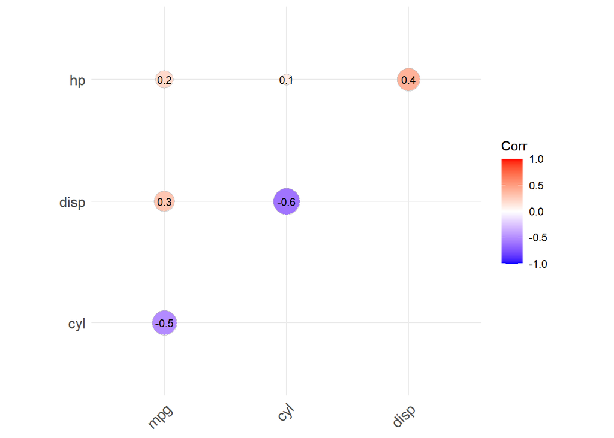

```r
cor_matrix <- matrix(c(
  1, -0.5, 0.3, 0.2,
  -0.5,  1, -0.6, 0.1,
   0.3, -0.6, 1,   0.4,
   0.2,  0.1, 0.4, 1
), nrow = 4, byrow = TRUE,
dimnames = list(c('mpg','cyl','disp','hp'),
                c('mpg','cyl','disp','hp')))

ggcorrplot(cor_matrix,
           method   = 'circle',
           type     = 'upper',
           lab      = TRUE,
           lab_size = 3,
           colors   = c('blue','white','red'))
```

## 3 Excel 数据相关性热力图

> 读取 Excel 中的相关性矩阵，计算 *p*-值并在不显著单元格留空。配色采用马卡龙色系。

```r
file_path <- 'G:/18keyan/picture/1.xlsx'  # 修改为实际路径

correlation_data <- read_excel(file_path, sheet = 'Sheet9', range = 'B1:H8')
row_titles <- read_excel(file_path, sheet = 'Sheet9', range = 'A1:A8')[[1]]
col_titles <- row_titles
rownames(correlation_data) <- row_titles; colnames(correlation_data) <- col_titles

p.mat <- round(cor_pmat(t(correlation_data)), 3)
macaron_colors <- c('#E4CDA7','#C6DEF1','#D8A7B1','#BFD8AF')

ggcorrplot(correlation_data, method='circle', type='full',
           lab = TRUE, lab_size = 5, outline.col='white',
           tl.cex = 14, ggtheme = theme_bw(),
           colors = macaron_colors, p.mat=p.mat, insig='blank')
```

## 4 层次聚类树状图

```r
library(tidyverse)
library(factoextra)
dd <-  mtcars %>% scale() %>% dist(method = "euclidean")
hc <- hclust(dd, method = "ward.D2")
```

### 4.2 圆形树状图

> 相同聚类结果以放射状展示，易观察整体层级关系。

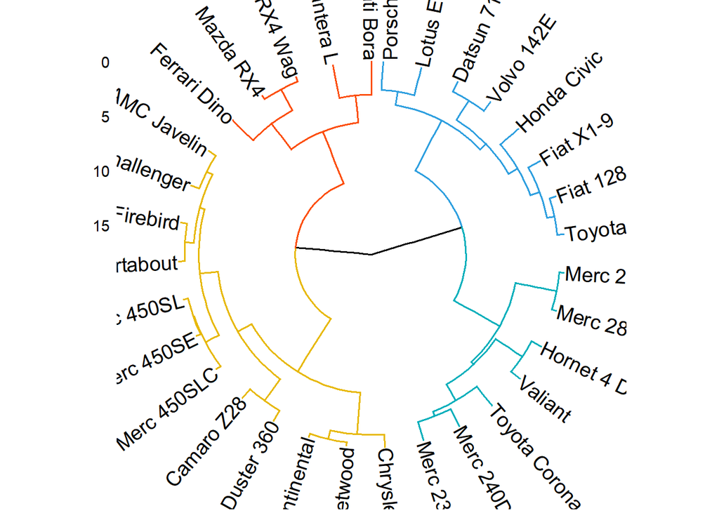

```r
par(mar = rep(300,4))
fviz_dend(hc, cex = 1.0, k = 4,
          color_labels_by_k = FALSE, # 数据标签也根据颜色设定
          k_colors = c("#2E9FDF", "#00AFBB", "#E7B800", "#FC4E07"),
          type = "circular",#phylogenic",
          labels_track_height = 0.1,
          repel = TRUE,
          rect_lty = 0.3)
```

## 5 因子权重可视化

### 5.1 箱线图 + 抖动

> 展示 4 种指标的分布，并叠加各因子散点。

```r
# 假设 clean_data 已生成
df_long <- reshape2::melt(clean_data, id.vars='Factor',
                          measure.vars = c('Zero_Order','Partial','importance','Tolerance_Trans'))
df_long$value <- as.numeric(df_long$value)
soft_cols <- c('#B5C4B1','#D6A2AD','#A7C7E7','#E6CBA8','#C3B1E1')

ggplot(df_long, aes(variable, value, fill=variable)) +
  geom_boxplot(alpha=.5, outlier.shape = NA) +
  geom_jitter(aes(color=Factor), width=.2, size=2) +
  scale_fill_manual(values=c('#E4CDA7','#C6DEF1','#D8A7B1','#BFD8AF')) +
  scale_color_manual(values=soft_cols) +
  theme_bw() + xlab('指标') + ylab('得分')
```

### 5.2 绘制条形图 + 误差线 + 数据点

```r
fac_data <- read_excel(file_path, sheet=10)
fac_data$权重计算方法[2:6]  <- '分类回归'
fac_data$权重计算方法[7:9]  <- '熵权法'
fac_data$权重计算方法[10:11] <- '自定义'

df_clean <- fac_data %>% select(权重计算方法, 因子权重) %>% filter(!is.na(权重计算方法))

# 计算均值和标准差
df_summary <- df_clean %>%
  group_by(权重计算方法) %>%
  summarise(
    平均因子权重 = mean(因子权重, na.rm = TRUE),
    标准差 = sd(因子权重, na.rm = TRUE)
  )


ggplot(df_summary, aes(x = `权重计算方法`, y = `平均因子权重`, fill = `权重计算方法`)) +
  geom_bar(stat = "identity", alpha = 0.8, width = 0.6) +  # 条形图
  geom_errorbar(aes(ymin = 平均因子权重 - 标准差, ymax = 平均因子权重 + 标准差),
                width = 0.2, size = 1, color = "black") +  # 误差线
  geom_jitter(data = df_clean, aes(x = `权重计算方法`, y = `因子权重`),
              width = 0, shape = 21, size = 4.5, alpha = 0.8, color = "black") +  # 数据点
  xlab("权重计算方法") +
  ylab("因子权重") +
  theme_minimal() +
  theme(legend.position = "right", text = element_text(size = 14)) +
  scale_fill_manual(values = c("#E4CDA7", "#C6DEF1", "#BFD8AF"))  # 颜色设置
```

### 提琴图

先进行数据提取与清洗

```r
df <- read_excel(file_path, sheet=6)
# 使用正则表达式拆分 "前20要素（要素出现频率）" 列
# 1. 先拆分 "前20要素（要素出现频率）" 列，提取所有的 "要素名称" 和 "出现频率"
df_clean <- df %>%
  mutate(要素列表 = strsplit(`前20要素（要素出现频率）`, "(?<=\\))", perl = TRUE)) %>%  # 按右括号拆分
  unnest(要素列表) %>%  # 展开为多行
  mutate(
    要素名称 = str_extract(要素列表, "[\u4e00-\u9fa5]+"),  # 提取中文部分
    出现频率 = str_extract(要素列表, "\\d+") %>% as.numeric()  # 提取数字部分
  ) %>%
  select(-要素列表)  # 删除拆分中间列
# **去除 NA 行**
df_clean <- df_clean %>% filter(!is.na(小类))

# 查看数据
print(df_clean)
```

```r
# **对 “出现频率” 进行标准化 (Z-score 标准化)**
df_clean <- df_clean %>%
  mutate(标准化 = (出现频率 - mean(出现频率, na.rm = TRUE)) / sd(出现频率, na.rm = TRUE))



# 选取前7个独立的小类
top7_classes <- df_clean %>%
  distinct(小类) %>%  # 确保小类唯一
  slice_head(n = 6)  # 选取前7个不同的小类

# 过滤数据集，仅保留前7个小类
df_subset <- df_clean %>%
  filter(小类 %in% top7_classes$小类)
df_subset <- df_subset %>% filter(row_number() != 1 | !is.na(小类))

# 选取第 8-14 个小类的数据
df_subset <- df_clean %>%
  filter(小类 %in% unique(小类)[1:6])
```

最后进行提琴可视化展示

```r
# 设置莫兰迪色系
morandi_colors <- c("#A8B5C3", "#C9A9A6", "#D6C6B4", "#B5C4B1", "#E8D0A9", "#A3C1AD", "#C0B2B5")
# 绘制提琴图
ggplot(df_subset, aes(x = 小类, y = 出现频率, fill = 小类)) +
  geom_violin(trim = FALSE, alpha = 0.8, width =1.2,aes(linetype = NA)) +  # 提琴图
  geom_jitter(shape = 21, size = 2, position = position_jitter(0.2), color = "black", alpha = 0.6) +  # 让数据点分布得更清晰
  scale_fill_manual(values = morandi_colors) +  # 设置莫兰迪配色
  labs(y = "出现频率") +
  theme_minimal() +  # 极简主题
  theme(  # 旋转x轴标签
        axis.text.x = element_text(size = 32,angle = 30, hjust =1),  # **X轴刻度字体大小**
        axis.text.y = element_text(size = 28),  # **Y轴刻度字体大小**
        axis.title.x = element_blank(),
        #axis.title.x = element_text(size = 24), # **X轴标题字体大小**
        axis.title.y = element_text(size = 26),
        legend.position = "none")  # 隐藏图例
```

## 6 桑基图示例

### 6.1 三系统 → 管控策略

```r
ggplot(df2, aes(x = x, next_x = next_x, node=node, next_node=next_node,
                fill=node, label=node)) +
  geom_sankey(flow.alpha=.5, smooth=7, width=.1) +
  geom_sankey_text(size=4) +
  scale_fill_manual(values = mocol) +
  theme_void()
```

### 6.2 因子编号 ↔︎ 景观风景区

数据清洗+前期处理

```r
df <- read_excel(file_path, sheet = 3)
head(df)

library(tidyr)

# 合并三列到一列
df_long <- df %>%
  pivot_longer(cols = starts_with("主要景观类型（编号/编号/…）"),
               names_to = "景观类型编号",  # 新列名称
               values_to = "景观类型值")  # 新列值

# 查看结果
head(df_long)
# 删除"景观类型值"为NA的行，并删除"景观类型编号"列
df_long <- df_long %>%
  filter(!is.na(景观类型值)) %>%  # 删除景观类型值为NA的行
  select(-景观类型编号)  # 删除景观类型编号列
# 确保所有列都没有重复值
df_long_clean <- df_long %>%
  distinct(景观风貌区, 主要特征区域编号, 景观类型值,编号, 因子类型, 因子种类) %>%
  filter(!is.na(景观类型值))
```

```r
df1 <- to_lodes_form(df_long_clean, axes = 1:6, id = "value")
head(df1)
df1$stratum <- factor(df1$stratum, levels = unique(c(
  rev(unique(df_long_clean$景观风貌区)),
  rev(unique(df_long_clean$主要特征区域编号)),
  rev(unique(df_long_clean$编号)),
  rev(unique(df_long_clean$景观类型值)),
  rev(unique(df_long_clean$因子类型)),
  rev(unique(df_long_clean$因子种类))
)))
# 将景观类型值列转换为字符型
df_long$景观类型值 <- as.character(df_long$景观类型值)

# 使用clean数据重新生成df2
df2 <- df_long_clean %>% make_long("景观风貌区", "主要特征区域编号", "景观类型值", "编号","因子类型","因子种类" )

# 更新因子级别
df2$node <- factor(df2$node, levels = c(rev(unique(df_long$景观风貌区)),
                                        rev(unique(df_long$主要特征区域编号)),
                                        rev(unique(df_long$编号)),
                                        rev(unique(df_long$景观类型值)),
                                        rev(unique(df_long$因子类型)),
                                        rev(unique(df_long$因子种类))))
df2$node <- factor(df2$node, levels = unique(c(
  rev(unique(df_long$景观风貌区)),
  rev(unique(df_long$主要特征区域编号)),
  rev(unique(df_long$编号)),
  rev(unique(df_long$景观类型值)),
  rev(unique(df_long$因子类型)),
  rev(unique(df_long$因子种类))
)))
```

```r
ggplot(df1, aes(x = x, fill=stratum, label=stratum,
               stratum = stratum, alluvium  = value))+#数据
  geom_flow(width = 0.2,#连线宽度
            curve_type = "sine",#曲线形状，有linear、cubic、quintic、sine、arctangent、sigmoid几种类型可供调整
            alpha = 0.8,#透明度
            color = 'white',#间隔颜色
            size = 0.05)+#间隔宽度
  geom_stratum(width = 0.2)+#图中方块的宽度
  geom_text(stat = 'stratum', size = 3,color = 'black')+
  scale_fill_manual(values = mocol)+#自定义颜色
  theme_void()+#主题（无轴及网格线）
  theme(legend.position = 'none')#去除图例
```

## 7 结语

以上示例涵盖相关性热力图、层次聚类与多种桑基图，可作为 GIS/统计可视化的模板。如有问题或改进建议，欢迎提出！